# Feature Importance Techniques

Feature importances are useful tools to interpret machine learning models. Here, we explore some of the widely used techniques like :

**[1. Spearman's Rank Correlation](#spearman)**

**[2. PCA](#pca)**

**[3. mRMR](#mrmr)**

**[4. Drop Column Importance](#dropcol)**

**[5. Permutation Importance](#perm)**

**[6. Shap Importance](#shap)**

We then initiate a diccussion on the efficiency of these techniques and explore methods that enhance our in-depth understanding.

**[7. Comparing feature importance techniques - Top N feature loss ](#comp)**

**[8. Automatic Feature Selection](#afs)**

**[9. Variance in Feature Importances](#var)**

**[10. Empirical P-Values](#pval)**

We will use the breast cancer dataset for this analysis.

```python
import pandas as pd
import numpy as np
from sklearn.datasets import load_breast_cancer
from typing import Mapping
from matplotlib import pyplot as plt
%matplotlib inline
plt.style.use('seaborn-whitegrid')
from sklearn.model_selection import train_test_split
from sklearn.decomposition import PCA
from sklearn.preprocessing import StandardScaler
from sklearn.ensemble import RandomForestClassifier
from sklearn.metrics import accuracy_score, log_loss
from sklearn.base import clone
import shap
```

We will add a feature 'random' with randomised values to check the relative scoring given to it by each technique.

```python
## load cancer data
cancer = load_breast_cancer()
X_df = pd.DataFrame(cancer.data, columns=cancer.feature_names)
## Adding a random column to get an insight as to how each techinque deals with it.
X_df.loc[:, 'random'] = np.random.rand(X_df.shape[0])
y_df = pd.DataFrame(cancer.target, columns=["target"])
feat = list(cancer.feature_names) + ['random','target']
cancer_df = pd.concat([X_df, y_df], ignore_index=True, sort=False, axis=1)
cancer_df.columns = feat
cancer_df.head()
```

|  | mean radius | mean texture | mean perimeter | mean area | mean smoothness | mean compactness | mean concavity | mean concave points | mean symmetry | mean fractal dimension | ... | worst perimeter | worst area | worst smoothness | worst compactness | worst concavity | worst concave points | worst symmetry | worst fractal dimension | random | target |
| --- | --- | --- | --- | --- | --- | --- | --- | --- | --- | --- | --- | --- | --- | --- | --- | --- | --- | --- | --- | --- | --- |
| 0 | 17.99 | 10.38 | 122.80 | 1001.0 | 0.11840 | 0.27760 | 0.3001 | 0.14710 | 0.2419 | 0.07871 | ... | 184.60 | 2019.0 | 0.1622 | 0.6656 | 0.7119 | 0.2654 | 0.4601 | 0.11890 | 0.678325 | 0 |
| 1 | 20.57 | 17.77 | 132.90 | 1326.0 | 0.08474 | 0.07864 | 0.0869 | 0.07017 | 0.1812 | 0.05667 | ... | 158.80 | 1956.0 | 0.1238 | 0.1866 | 0.2416 | 0.1860 | 0.2750 | 0.08902 | 0.151145 | 0 |
| 2 | 19.69 | 21.25 | 130.00 | 1203.0 | 0.10960 | 0.15990 | 0.1974 | 0.12790 | 0.2069 | 0.05999 | ... | 152.50 | 1709.0 | 0.1444 | 0.4245 | 0.4504 | 0.2430 | 0.3613 | 0.08758 | 0.856280 | 0 |
| 3 | 11.42 | 20.38 | 77.58 | 386.1 | 0.14250 | 0.28390 | 0.2414 | 0.10520 | 0.2597 | 0.09744 | ... | 98.87 | 567.7 | 0.2098 | 0.8663 | 0.6869 | 0.2575 | 0.6638 | 0.17300 | 0.381429 | 0 |
| 4 | 20.29 | 14.34 | 135.10 | 1297.0 | 0.10030 | 0.13280 | 0.1980 | 0.10430 | 0.1809 | 0.05883 | ... | 152.20 | 1575.0 | 0.1374 | 0.2050 | 0.4000 | 0.1625 | 0.2364 | 0.07678 | 0.634791 | 0 |

5 rows × 32 columns

```python
## train validation split
train_df, val_df = train_test_split(cancer_df, test_size=0.2, random_state=42, stratify=cancer_df.target)
train_df.shape, val_df.shape
```

```
((455, 32), (114, 32))
```

## 1. Spearman's Rank Correlation

### $ r_s = \rho_{\operatorname{rg}_X,\operatorname{rg}_Y} = \frac{\operatorname{cov}(\operatorname{rg}_X, \operatorname{rg}_Y)} {\sigma_{\operatorname{rg}_X} \sigma_{\operatorname{rg}_Y}} $

where $\rho$ denotes the usual **Pearson correlation coefficient** but applied to the rank variables, $\operatorname{cov}(\operatorname{rg}_X, \operatorname{rg}_Y)$ is the **covariance** of the rank variables and $\sigma_{\operatorname{rg}_X}$ and $\sigma_{\operatorname{rg}_Y}$ are the **standard deviations** of the rank variables.

```python
def spearman_corr(df: pd.DataFrame, target:str) -> np.array:
    "Returns an array of spearman's rank correlation for each of the features calculated w.r.t. the input column"
    df = df.copy()
    corr = {}
    cols = [col for col in df.columns if col != target]
    rank_target = df[target].rank(axis=0, method = 'min')
    for col in cols:
        rank_feat = df[col].rank(axis=0, method='average') ## average out the rank for values with same rank
        cov = rank_feat.cov(rank_target)
        std_target, std_feat = rank_target.std(), rank_feat.std()
        corr_feat = cov / std_target / std_feat
        corr[col] = abs(corr_feat)
    return dict(sorted(corr.items(), key=lambda x: x[1], reverse=True))
```

```python
## get importances in a dict
corr_spearman = spearman_corr(df=cancer_df, target='target')
```

```python
### checking against pandas corr function
corr = np.array([val for val in corr_spearman.values()])
corr_df = cancer_df.corr(method='spearman')['target'].reset_index()
corr_df.columns = ['col','target']
corr_df.target = np.abs(corr_df.target).sort_values()
corr_df = corr_df.sort_values(by='target', ascending=False)
corr_df = corr_df.loc[corr_df.col != 'target', :] ## remove correlation with itself
np.allclose(corr_df.target, corr)
```

```
True
```

Lets plot the importance scores. Horizontal bar plots are a nice way to visualize importance scores.

```python
def plot_feat_imp(importances:dict, title:str, show_values=False) -> plt:
    "Returns a horizontal bar plot of feature importances"
    fig, ax = plt.subplots(figsize=(15,10))
    ax.barh(np.array([val for val in importances.keys()]),
            np.array([val for val in importances.values()]), color='lightblue') # Horizontal Bar Plot
    for s in ['top','bottom','left','right']:
        ax.spines[s].set_visible(False) # Remove axes splines
    ax.xaxis.set_ticks_position('none') # Remove x,y Ticks
    ax.yaxis.set_ticks_position('none')
    ax.xaxis.set_tick_params(pad=5) # Add padding between axes and labels
    ax.yaxis.set_tick_params(pad=10)
    ax.grid(b=True, color='grey', linestyle='-.', linewidth=0.5, alpha=0.2) # Add x,y gridlines
    ax.invert_yaxis()# Show top values
    ax.set_title(title, loc='left', pad=-5, fontweight='bold', fontsize=15)# Add Plot Title
    if show_values:
        for i in ax.patches: # Add annotation to bars
            if i.get_width() < 0: a = i.get_width()-0.035
            else: a = i.get_width()+0.005
            ax.text(a, i.get_y()+0.6, str(round((i.get_width()), 2)), fontsize=10, fontweight='bold', color='grey')
    fig.text(0.9, 0.15, '@skumar18', fontsize=12, color='grey', ha='right', va='bottom', alpha=0.5) # Add Text watermark
    return plt
```

```
<module 'matplotlib.pyplot' from '/Users/MrMndFkr/anaconda3/lib/python3.7/site-packages/matplotlib/pyplot.py'>
```

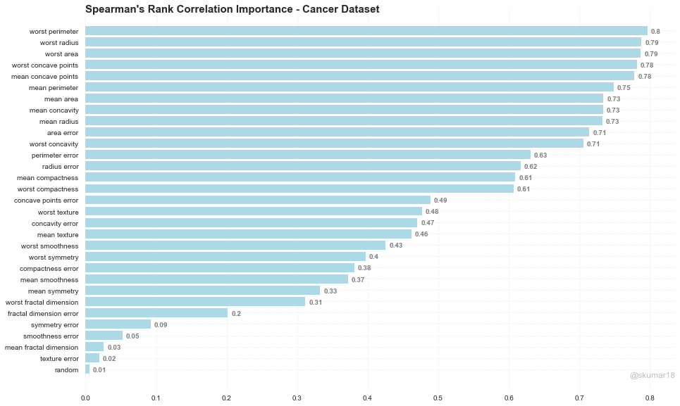

```python
plot_feat_imp(corr_spearman, "Spearman's Rank Correlation Importance - Cancer Dataset", show_values=True)
```

### Advantages

While Pearson's correlation assesses linear relationships, Spearman's correlation assesses monotonic relationships i.e. it looks at how much target variable Y changes with increaseing values of feature X.

Spearman's correlation is more robust to outliers when compared to the Pearson correlation coefficient because it reduces the values to ranks thereby diluting the effect of outliers.

### Disadvantages

This method is measuring single-feature relevance importance and works well for independent features, but suffers in the presence of codependent features.

Groups of features with similar relationships to the response variable receive the same or similar ranks, even though just one should be considered important.

## 2. PCA

**Principal component analysis** (PCA) is a statistical procedure that uses an orthogonal transformation to convert a set of observations of possibly correlated variables into a set of values of linearly uncorrelated variables called principal components

This transformation is done such that the first principal component has the largest possible variance and each succeeding component in turn has the highest variance possible under the constraint that it is orthogonal to the preceding components.

For the component with highest variance (called first principal component), we calculate the contributions from each of the features and the feature with highest absolute contribution is considered the most important.

```python
# scale data before PCA
scaler = StandardScaler()
cols = [col for col in train_df.columns if col != 'target']
train_x_scaled = scaler.fit_transform(train_df.loc[:, cols])
val_x_scaled = scaler.transform(val_df.loc[:, cols])
```

```python
## fit PCA and look for the coefficients of features for the first principal component
pca = PCA(n_components=0.9, random_state=42)
pca.fit(train_x_scaled)
print(abs( pca.components_[0]))
```

```
[0.21762711 0.09547082 0.2264272  0.21985421 0.14854907 0.24220046
 0.25776625 0.26136448 0.14467215 0.07096583 0.20339574 0.01097084
 0.20844733 0.20353005 0.01370965 0.16977621 0.15459906 0.18400008
 0.05413952 0.09918049 0.22608256 0.09746566 0.23484671 0.22283325
 0.12858792 0.21092856 0.23010277 0.24984962 0.13039161 0.13319284
 0.00272804]
```

```python
## get importances in a dict
pca_importances = abs(pca.components_[0])
pca_featimp = {cols[i]:pca_importances[i] for i in range(len(cols))}
pca_featimp = dict(sorted(pca_featimp.items(), key=lambda x: x[1], reverse=True))
```

```
<module 'matplotlib.pyplot' from '/Users/MrMndFkr/anaconda3/lib/python3.7/site-packages/matplotlib/pyplot.py'>
```

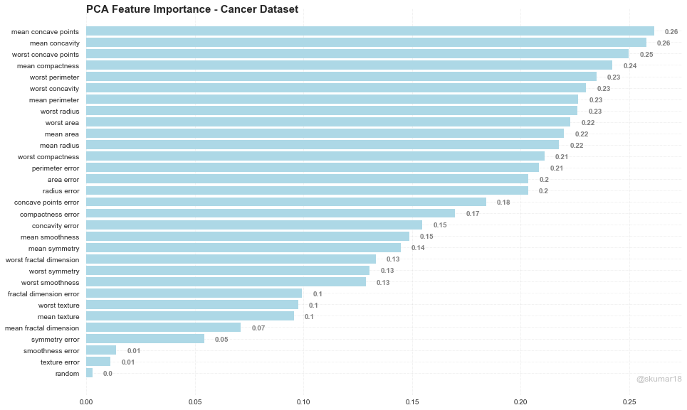

```python
plot_feat_imp(pca_featimp, "PCA Feature Importance - Cancer Dataset", show_values=True)
```

The random feature we introduced gets a low score because it does not explain any variance in the given dataset.

### Advantages

It is very versatile and works really well on any dataset.

### Disadvantages

We need to tune the cumulative explained variance to get principal components, which can be tricky sometimes.

## 3. mRMR

This technique ranks features not just by relevance (correlation with target variable) but also by low redundancy (amount of information shared between codependant features).

mRMR can use either mutual information, correlation, or distance/similarity scores to select features. The aim is to penalise a feature's relevancy by its redundancy in the presence of the other selected features

**Relevance** of a feature set $S$ for the class $c$ is defined by the average value of all mutual information values between the individual feature $f_i$ and the class $c$ as follows :

#### $D(S,c) = \frac{1}{|S|}\sum_{f_{i}\in S}I(f_{i};c)$ $

**Redundancy** of all features in the set $S$ is the average value of all mutual information values between the feature $f_i$ and the feature $f_j$:

#### $R(S) = \frac{1}{|S|^{2}}\sum_{f_{i},f_{j}\in S}I(f_{i};f_{j})$

The mRMR criterion is a combination of two measures given above and is defined as follows:

$$ mRMR= \max_{S} \left[\frac{1}{|S|}\sum_{f_{i}\in S}I(f_{i};c) - \frac{1}{|S|^{2}}\sum_{f_{i},f_{j}\in S}I(f_{i};f_{j})\right]$$

Suppose that there are n full-set features. Let $x_i$ be the set membership indicator function for feature $f_i$, so that $x_i=1$ indicates presence and $x_i=0$ indicates absence of the feature $f_i$ in the globally optimal feature set. Let $c_{i}=I(f_i;c)$ and $a_{ij}=I(f_{i};f_{j})$. The above may then be written as an optimization problem:

$$ mRMR= \max_{x\in \{0,1\}^{n}} \left[\frac{\sum^{n}_{i=1}c_{i}x_{i}}{\sum^{n}_{i=1}x_{i}} - \frac{\sum^{n}_{i,j=1}a_{ij}x_{i}x_{j}} {(\sum^{n}_{i=1}x_{i})^{2}}\right]$$

```python
def mRMR(df:pd.DataFrame, target:str) -> dict:
    """
    Returns a dictionary of features with their mRMR importances calcuated using the Spearman's correlation metric
    df: input data
    target: name of target column
    """
    mrmr_values = dict()
    selected_feat = []
    candidates = [col for col in df.columns if col != target]
    corr_w_target = spearman_corr(df=df, target=target)
    first_feat = list(corr_w_target.keys())[0]
    selected_feat.append(first_feat)
    rest_feat = [col for col in candidates if col not in selected_feat]
    mrmr_values[first_feat] = corr_w_target[first_feat]
    i = 0
    print(f'iter {i} selected feature: {first_feat} with mRMR = {mrmr_values[first_feat]:.3f}')
    while len(rest_feat) > 0:
        i += 1
        feat_mrmr = []
        for fi in rest_feat:
            redundancy = 0
            relevance = corr_w_target[fi]
            for fj in selected_feat:
                dict_red = spearman_corr(df=df.drop(columns=target), target=fj)
                redundancy += dict_red[fi]
            redundancy = redundancy / len(selected_feat)
            mrmr = relevance - redundancy
            feat_mrmr.append(mrmr)
        selected_feature = rest_feat[np.argmax(feat_mrmr)]
        mrmr_values[selected_feature] = np.max(feat_mrmr)
        print(f'iter {i} selected feature: {selected_feature} with mRMR = {mrmr_values[selected_feature]:.3f}')
        rest_feat = [col for col in rest_feat if col != selected_feature]
        selected_feat.append(selected_feature)
    return mrmr_values, selected_feat
```

```python
mrmr_imp, selected_feat = mRMR(df=train_df, target='target')
```

```
iter 0 selected feature: worst perimeter with mRMR = 0.798
iter 1 selected feature: worst smoothness with mRMR = 0.208
iter 2 selected feature: area error with mRMR = 0.243
iter 3 selected feature: mean texture with mRMR = 0.181
iter 4 selected feature: worst concave points with mRMR = 0.222
iter 5 selected feature: worst area with mRMR = 0.170
iter 6 selected feature: mean concave points with mRMR = 0.112
iter 7 selected feature: worst symmetry with mRMR = 0.102
iter 8 selected feature: worst radius with mRMR = 0.145
iter 9 selected feature: radius error with mRMR = 0.105
iter 10 selected feature: worst concavity with mRMR = 0.109
iter 11 selected feature: worst texture with mRMR = 0.107
iter 12 selected feature: mean area with mRMR = 0.133
iter 13 selected feature: mean perimeter with mRMR = 0.102
iter 14 selected feature: mean concavity with mRMR = 0.095
iter 15 selected feature: mean radius with mRMR = 0.076
iter 16 selected feature: mean smoothness with mRMR = 0.083
iter 17 selected feature: perimeter error with mRMR = 0.086
iter 18 selected feature: worst compactness with mRMR = 0.062
iter 19 selected feature: mean symmetry with mRMR = 0.041
iter 20 selected feature: mean compactness with mRMR = 0.028
iter 21 selected feature: concave points error with mRMR = 0.013
iter 22 selected feature: random with mRMR = 0.005
iter 23 selected feature: worst fractal dimension with mRMR = -0.002
iter 24 selected feature: concavity error with mRMR = -0.005
iter 25 selected feature: symmetry error with mRMR = -0.073
iter 26 selected feature: compactness error with mRMR = -0.071
iter 27 selected feature: fractal dimension error with mRMR = -0.121
iter 28 selected feature: smoothness error with mRMR = -0.135
iter 29 selected feature: texture error with mRMR = -0.172
iter 30 selected feature: mean fractal dimension with mRMR = -0.292
```

```
<module 'matplotlib.pyplot' from '/Users/MrMndFkr/anaconda3/lib/python3.7/site-packages/matplotlib/pyplot.py'>
```

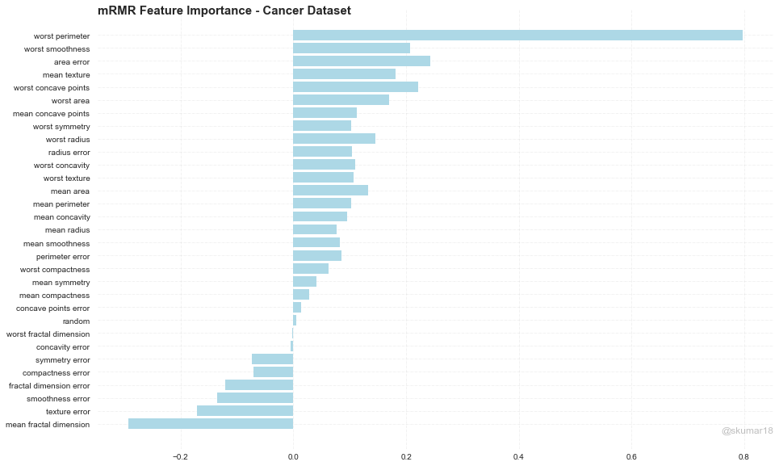

```python
plot_feat_imp(mrmr_imp, "mRMR Feature Importance - Cancer Dataset")
```

It must be noted that the mRMR importance values dont mean anything, just the order in which we selected features matters. In the plot, the order of selected features is from top to bottom.

### Advantages

mRMR can be used with any scoring mechanism like mutual information, correlation, or distance/similarity.

### Disadvantages

The mRMR importance values don't mean anything and hence its difficult to quantify relative importance of each feature.

## 4. Drop Column Importance

In this technique, we get a baseline metric from a model on the whole data. We then drop features one by one, retrain the model and measure the change in that metric.

```python
## train rf model with oob score for drop column feature importance
rf_oob = RandomForestClassifier(n_estimators=30, oob_score=True, random_state=42)
rf_oob.fit(train_df.loc[:, cols], train_df.target)
val_preds = rf_oob.predict(val_df.loc[:, cols])
train_preds = rf_oob.predict(train_df.loc[:, cols])
acc_train = accuracy_score(train_df.target, train_preds)
acc_val = accuracy_score(val_df.target, val_preds)
print(f'train accuracy: {acc_train:.3f} validation accuracy: {acc_val:.3f}')
```

```
train accuracy: 1.000 validation accuracy: 0.956
```

```python
def dropcol_importances(rf, df:pd.DataFrame, target:str) -> dict:
    """
    Returns a dictionary of feature : importance scores for given random forest model, initialised with oob_score=True
    """
    feat_imp = dict()
    rf_ = clone(rf)
    rf_.random_state = 999
    X_train = df.drop(columns=target)
    Y_train = df[target]
    rf_.fit(X_train, Y_train)
    baseline = rf_.oob_score_
    imp = []
    for col in X_train.columns:
        X = X_train.drop(columns=col)
        rf_ = clone(rf)
        rf_.random_state = 999
        rf_.fit(X, Y_train)
        o = rf_.oob_score_
        feat_imp[col] = baseline - o
    return dict(sorted(feat_imp.items(), key=lambda x: x[1], reverse=True))
```

```python
## Get importances in a dict
dropcol_imp = dropcol_importances(rf=rf_oob, df=train_df, target='target')
```

```
<module 'matplotlib.pyplot' from '/Users/MrMndFkr/anaconda3/lib/python3.7/site-packages/matplotlib/pyplot.py'>
```

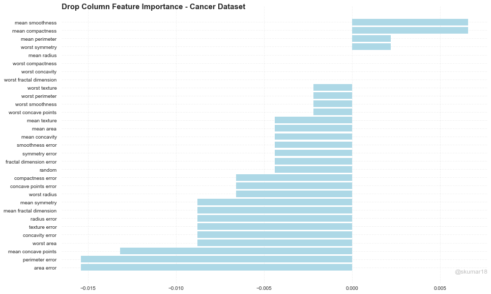

```python
plot_feat_imp(dropcol_imp, "Drop Column Feature Importance - Cancer Dataset")
```

Negative importance scores for a particular feature mean that the model performs **better** when these features are dropped.

### Advantages

Negative importances mean the feature has negative effect on the model and can be dropped.

### Disadvantages

This technique is computationally expensive since the model has to be retrained every time we drop a feature.

It gives near zero importance to highly correlated / identical columns and we should be careful before dropping such features.

## 5. Permutation Importance

In this technique, we get a baseline metric from a model on the whole data. We then permute features one by one and use the model to measure the change in that metric. Models are not retrained at each step and this makes this technique pretty fast.

```python
## train rf model without oob score for permutation feature importance
rf = RandomForestClassifier(n_estimators=30, random_state=42)
rf.fit(train_df.loc[:, cols], train_df.target)
val_preds = rf.predict(val_df.loc[:, cols])
train_preds = rf.predict(train_df.loc[:, cols])
acc_train = accuracy_score(train_df.target, train_preds)
acc_val = accuracy_score(val_df.target, val_preds)
print(f'train accuracy: {acc_train:.3f} validation accuracy: {acc_val:.3f}')
```

```
train accuracy: 1.000 validation accuracy: 0.956
```

```python
def permutation_importance(model, val:pd.DataFrame, target:str, metric=accuracy_score) -> dict:
    """
    Returns a dictionary of feature : importance scores for given model, metric and validation dataset
    """
    val = val.copy()
    baseline = metric(val[target], model.predict(val.drop(columns=target)))
    feat_imp = dict()
    features = [col for col in val.columns if col != target]
    for col in features:
        col_saved = val[col].copy()
        val[col] = np.random.permutation(val[col])
        new_score = metric(val[target], model.predict(val.drop(columns=target)))
        val[col] = col_saved
        feat_imp[col] = baseline - new_score
    return dict(sorted(feat_imp.items(), key=lambda x: x[1], reverse=True))
```

```python
## Get importances in a dict
perm_imp = permutation_importance(rf, val=val_df, target='target', metric=accuracy_score)
```

```
<module 'matplotlib.pyplot' from '/Users/MrMndFkr/anaconda3/lib/python3.7/site-packages/matplotlib/pyplot.py'>
```

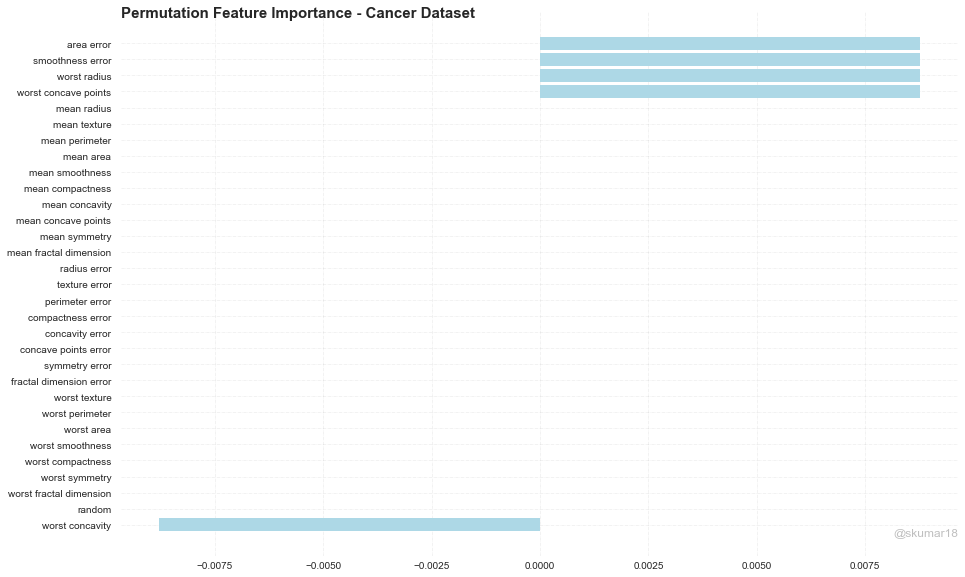

```python
plot_feat_imp(perm_imp, "Permutation Feature Importance - Cancer Dataset", show_values=False)
```

### Advantages

Since we dont need to retrain the model for every feature, it is very fast and efficient.

### Disadvantages

It gives near zero importance to highly correlated / identical columns and we should be careful before dropping such features.

## 6. SHAP Importance

SHAP or SHapley Additive exPlanations explain the prediction of an instance x by computing the contribution of each feature to the prediction.

The SHAP explanation method computes Shapley values from coalitional game theory for each record of each feature. The mean of absolute Shapley values for a feature give its importance w.r.t. target variable.

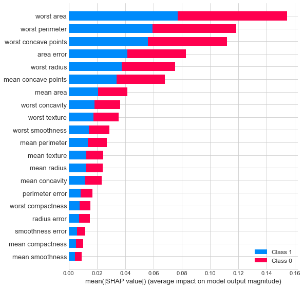

```python
shap_values = shap.TreeExplainer(rf, data=train_df.drop(columns='target')).shap_values(X=val_df.drop(columns='target')
                                                                , y=val_df['target'])
shap.summary_plot(shap_values, val_df.drop(columns='target'), plot_type="bar")
```

```python
## taking mean of absolute shap values for each record and then summing them up across two target classes
imp = np.sum(np.mean(np.abs(shap_values), axis=1), axis=0)
shap_imp = dict(zip([col for col in train_df.drop(columns='target').columns], imp))
shap_imp = dict(sorted(shap_imp.items(), key=lambda x: x[1], reverse=True))
```

```
<module 'matplotlib.pyplot' from '/Users/MrMndFkr/anaconda3/lib/python3.7/site-packages/matplotlib/pyplot.py'>
```

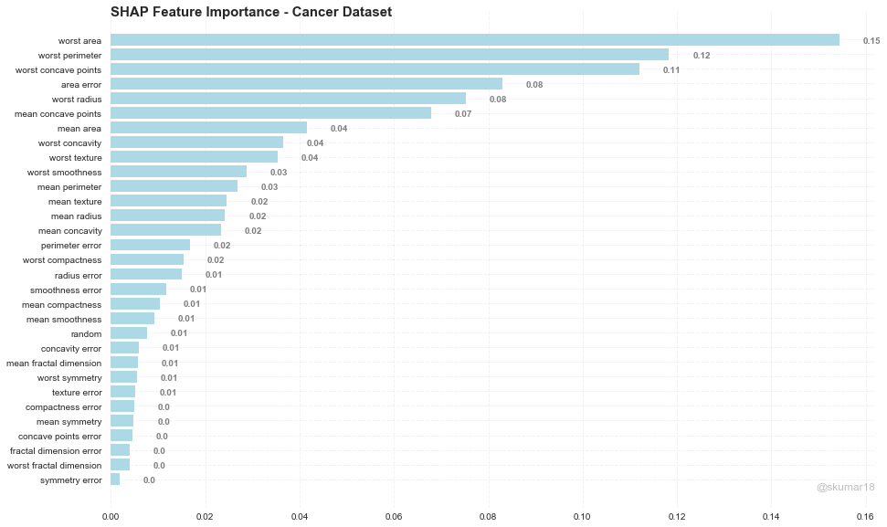

```python
plot_feat_imp(shap_imp, "SHAP Feature Importance - Cancer Dataset", show_values=True)
```

We see that there are some features ranked below the random feature and hence they can be dropped automatically.

## Advantages

SHAP is universal and can be applied to any algorithm. Moreover it gives importance scores to each and every record and is very insightful.

## Disadvantages

To understand SHAP we need to understand some concepts from Game Theory first, which is difficult for people.

## 7. Comparison of different techniques

Here, we train different models using the top 1,2,3 etc features and record the validation errors. A plot of the error values against the no of features selected will be a good way to compare these different strategies. The most effective technique will reach the lowest loss point in minimum number of features.

```python
def compare_top10(model, train:pd.DataFrame, val:pd.DataFrame, feat_imp:dict, target:str, metric=log_loss) -> list:
    """
    Returns a list of log-loss values for top 1,2,3,....,10 features taken from a sorted dictionary of feature importances.
    """
    loss_list = []
    train = train.copy()
    val = val.copy()
    for i in range(1, 11):
        model_ = clone(model)
        model_.random_state = 42
        features = [col for col in feat_imp.keys()][:i] ## select top i features
        model_.fit(train.loc[:, features], train[target])
        valid_proba = model_.predict_proba(val.loc[:, features])
        log_loss_valid = metric(val[target], valid_proba)
        loss_list.append(log_loss_valid)
    return loss_list
```

```python
# Sorting the spearman corr by abs value, getting loss after top 1,2,...N features dropped
corr_spearman = {key:abs(imp) for key,imp in corr_spearman.items()}
corr_spearman = dict(sorted(corr_spearman.items(), key=lambda x: x[1], reverse=True))
loss_spearman = compare_top10(model=rf, train=train_df, val=val_df, feat_imp=corr_spearman, target='target')
loss_pca = compare_top10(model=rf, train=train_df, val=val_df, feat_imp=pca_featimp, target='target')
loss_mrmr = compare_top10(model=rf, train=train_df, val=val_df, feat_imp=mrmr_imp, target='target')
loss_dropcol = compare_top10(model=rf_oob, train=train_df, val=val_df, feat_imp=dropcol_imp, target='target')
loss_permcol = compare_top10(model=rf, train=train_df, val=val_df, feat_imp=perm_imp, target='target')
loss_shap = compare_top10(model=rf, train=train_df, val=val_df, feat_imp=shap_imp, target='target')
```

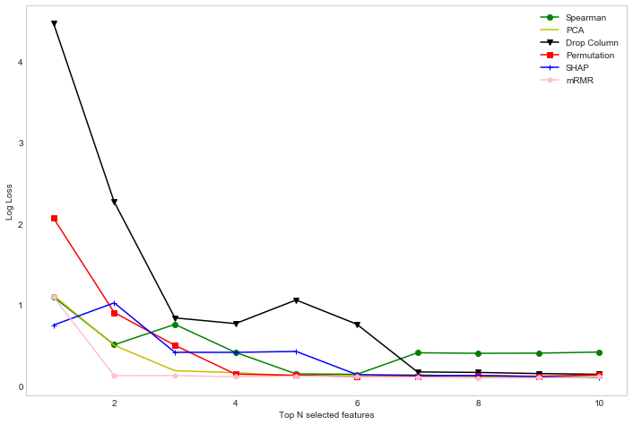

```python
# Plotting results
fig = plt.figure(figsize=(12,8))
ax = plt.axes()
plt.plot(range(1, len(loss_spearman)+1), loss_spearman, 'g', marker='o',  label='Spearman')
plt.plot(range(1, len(loss_pca)+1), loss_pca, 'y', marker='',  label='PCA')
plt.plot(range(1, len(loss_dropcol)+1), loss_dropcol, 'k', marker='v',  label='Drop Column')
plt.plot(range(1, len(loss_permcol)+1), loss_permcol, 'r', marker='s',  label='Permutation')
plt.plot(range(1, len(loss_shap)+1), loss_shap, 'b', marker='+',  label='SHAP')
plt.plot(range(1, len(loss_mrmr)+1), loss_mrmr, 'pink', marker='p',  label='mRMR')
ax.grid(False)
handles, labels = ax.get_legend_handles_labels()
ax.legend(handles, labels)
ax.set_ylabel('Log Loss', fontsize=10)
ax.set_xlabel('Top N selected features', fontsize=10)
plt.show()
```

## 8. Automatic Feature Selection

Here, we develop an automated mechanism to drop off unimportant features and keep the top k, for some k we don't know beforehand.

### Steps

1. get a baseline validation metric appropriate for a classifier or a regressor
2. get the feature importances
3. drop the lowest importance feature and retrain the model
4. re-compute the validation metric
5. If the validation metric is worse, then we have dropped one too many features. So we break the loop and revert back to the earlier configuration as the most optimal one

```python
def get_best_model(model, train:pd.DataFrame, val:pd.DataFrame, target:str , metric=log_loss) -> list:
    """
    Returns the best model obtained by dropping features one by one, feature with minimum shap importance is dropped
    and the new validation loss is checked against the previous loss value to check if dropping the feature decreased loss.
    """
    model_ = clone(model)
    model_.random_state = 42
    X_train = train.drop(columns=target)
    Y_train = train[target]
    X_val = val.drop(columns=target)
    Y_val = val[target]
    model_.fit(X_train, Y_train)
    preds = model_.predict_proba(X_val)
    val_loss = metric(Y_val, preds)
    shap_values = shap.TreeExplainer(model_, data=X_train).shap_values(X=X_val, y=Y_val, check_additivity=False)
    shap_imp = np.sum(np.mean(np.abs(shap_values), axis=1), axis=0) ## mean shap value for each feature
    feat = [col for col in X_val.columns]
    removed_feat = []
    i = 0
    while True:
        i += 1
        remove_feat = feat[np.argmin(shap_imp)]
        removed_feat.append(remove_feat)
        selected_feat = [col for col in feat if col not in removed_feat]
        print(f'Iter {i}: dropping feature: {remove_feat}')
        model_ = clone(model)
        model_.random_state = 42
        X_train_new = X_train.drop(columns=removed_feat)
        X_val_new = X_val.drop(columns=removed_feat)
        model_.fit(X_train_new, Y_train)
        preds_new = model_.predict_proba(X_val_new)
        val_loss_new = metric(Y_val, preds_new)
        if val_loss_new <= val_loss:
            print(f'Loss in last iter: {val_loss:.3f}, loss in this iter: {val_loss_new:.3f}')
            shap_values_new = shap.TreeExplainer(model_, data=X_train_new ).shap_values(X=X_val_new, y=Y_val,
                                                                                        check_additivity=False)
            shap_imp_new = np.sum(np.mean(np.abs(shap_values_new), axis=1), axis=0) ## mean shap value for each feature
            print(f'Loss decreased hence continuing to drop more features')
            shap_imp = shap_imp_new
            feat = [col for col in X_train_new.columns]
        else:
            removed_feat = [col for col in removed_feat if col != remove_feat]
            print(f'Loss in last iter: {val_loss:.3f}, loss in this iter: {val_loss_new:.3f}')
            print(f'Stopping iterations as loss did not decrease, dropped features = {removed_feat}')
            return model_, removed_feat
        val_loss = val_loss_new
```

```python
model, removed_feat = get_best_model(model=rf, train=train_df, val=val_df, target='target')
```

```
Iter 1: dropping feature: symmetry error
Loss in last iter: 0.117, loss in this iter: 0.114
Loss decreased hence continuing to drop more features
Iter 2: dropping feature: concave points error
Loss in last iter: 0.114, loss in this iter: 0.116
Stopping iterations as loss did not decrease, dropped features = ['symmetry error']
```

As seen from the function output, validation loss decreased when we dropped features 'symmetry error'. Loss increased when we further dropped feature 'concave points error' and hence we switched back to the earlier configuration as the most optimal model.

## 9. Variance in Feature Importances

We use bootstrapped data to get a distribution of feature importances. Calculating standard deviation of the distributions gives us errors in shap values for each feature.

```python
def get_std(model, train:pd.DataFrame, val:pd.DataFrame, target:str, metric=log_loss) -> (np.array, np.array):
    """
    Returns 1 standard deviation error values for shap importance values of each feature
    """
    shap_imp = np.zeros((100,val.shape[1] - 1))
    for i in range(100):
        idx = np.random.choice(range(val.shape[0]), size=val.shape[0], replace=True) ## booststrap
        val_new = val.iloc[idx, :]
        shap_values = shap.TreeExplainer(model, data=train.drop(columns=target)).shap_values(
                                        X=val_new.drop(columns=target), y=val_new[target], check_additivity=False)
        shap_imp[i] = np.sum(np.mean(np.abs(shap_values), axis=1), axis=0)
    return np.std(shap_imp, axis=0) ## calculate 1 standard deviation for each feature
```

```python
## get shap importances and std, store them in a dict of feature name : tuple of (value, std)
shap_imp = shap.TreeExplainer(rf, data=train_df.drop(columns='target')).shap_values(
                                        X=val_df.drop(columns='target'), y=val_df['target'])
shap_imp = np.sum(np.mean(np.abs(shap_imp), axis=1), axis=0)
shap_var = get_std(rf, train=train_df, val=val_df, target='target')
list_tuples = list(zip(shap_imp,shap_var))
shap_dict = dict(zip([col for col in val_df.drop(columns='target').columns], list_tuples))
shap_dict = dict(sorted(shap_dict.items(), key=lambda x: x[1][0], reverse=True))
```

```python
def plot_feat_imp_erros(importances:dict, title:str, show_values=False) -> plt:
    """
    Returns a plot of feature importances with error bars, importances is a dict of feature:(importance, error)
    """
    fig, ax = plt.subplots(figsize=(15,10))
    ax.barh(np.array([val for val in importances.keys()]),
            np.array([val[0] for val in importances.values()]),
            xerr=np.array([val[1] for val in importances.values()]), color='lightblue') # Horizontal Bar Plot
    for s in ['top','bottom','left','right']:
        ax.spines[s].set_visible(False) # Remove axes splines
    ax.xaxis.set_ticks_position('none') # Remove x,y Ticks
    ax.yaxis.set_ticks_position('none')
    ax.xaxis.set_tick_params(pad=5) # Add padding between axes and labels
    ax.yaxis.set_tick_params(pad=10)
    ax.grid(b=True, color='grey', linestyle='-.', linewidth=0.5, alpha=0.2) # Add x,y gridlines
    ax.invert_yaxis()# Show top values
    ax.set_title(title, loc='left', pad=-5, fontweight='bold', fontsize=15)# Add Plot Title
    if show_values:
        for i in ax.patches: # Add annotation to bars
            if i.get_width() < 0: a = i.get_width()-0.035
            else: a = i.get_width()+0.01
            ax.text(a, i.get_y()+0.6, str(round((i.get_width()), 2)), fontsize=10, fontweight='bold', color='grey')
    fig.text(0.9, 0.15, '@skumar18', fontsize=12, color='grey', ha='right', va='bottom', alpha=0.5) # Add Text watermark
    return plt
```

```
<module 'matplotlib.pyplot' from '/Users/MrMndFkr/anaconda3/lib/python3.7/site-packages/matplotlib/pyplot.py'>
```

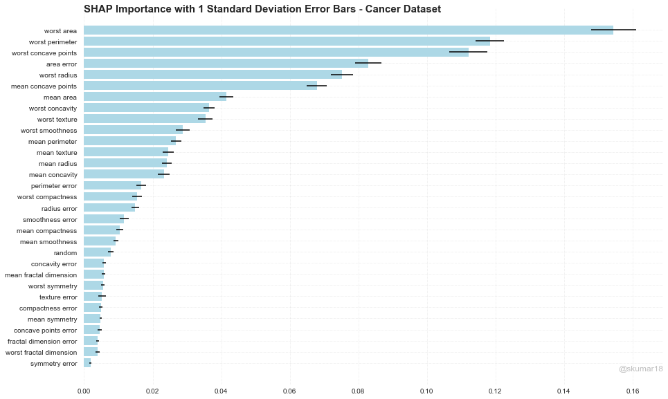

```python
plot_feat_imp_erros(importances=shap_dict,
                    title='SHAP Importance with 1 Standard Deviation Error Bars - Cancer Dataset')
```

## 10. Empirical P-Values

P-values associated with a feature's importance distribution will tell us whether the feature's importance is significant.

The Null distribution comes from suffling the target variable y, retraining model and then computing feature importances again.

We then count how many times a feature is as important or more important than the true future importance computed as a baseline. If the proportion comes out to be more than 5%, this means that there is a good chance that this value came out of the Null distribution and hence we deem that feature insignificant.

### Steps

```python
def p_values(model, train:pd.DataFrame, val:pd.DataFrame, target:str, metric=log_loss) -> (np.array, np.array):
    """
    Returns p-value, associated array of shap baseline values and new importance scores obtained by scrambling target (Null distribution)
    """
    shap_imp = np.zeros((100,val.shape[1] - 1))
    X_train = train.drop(columns=target)
    X_val = val.drop(columns=target)
    Y_val = val[target]
    shap_values_baseline = shap.TreeExplainer(model, data=X_train).shap_values(X=X_val, y=Y_val,
                                                                               check_additivity=False)
    shap_baseline = np.sum(np.mean(np.abs(shap_values_baseline), axis=1), axis=0)
    shap_baseline = shap_baseline / np.sum(shap_baseline) ## normalise for further comparison
    for i in range(100):
        Y_train = np.random.permutation(train[target])
        model_ = clone(model)
        model_.random_state = 42
        model_.fit(X_train, Y_train)
        shap_values = shap.TreeExplainer(model_, data=X_train).shap_values(X=X_val, y=Y_val, check_additivity=False)
        shap_imp[i] = np.sum(np.mean(np.abs(shap_values), axis=1), axis=0) ## recalculate and store shap
        shap_imp[i] = shap_imp[i] / np.sum(shap_imp[i]) ## Normalise for comparison
    diff = shap_baseline - shap_imp ## -ve values correspond to greater than baseline score
    p_values = np.sum(diff <= 0, axis=0) / 100 ## proportion of positive elements gives empirical p-value
    return p_values, shap_baseline, shap_imp
```

```python
p_values, shap_baseline, shap_imp = p_values(model=rf, train=train_df, val=val_df, target='target')
```

```python
def get_hist(p_values:np.array, baseline_score:np.array, imp_scores:np.ndarray, features:list, n:int) -> list:
    """
    Returns a Null distribution histogram for given feature index 'n', vertical line shows the baseline importance
    """
    list_plots = []
    fig,ax = plt.subplots(figsize=(12,8))
    _ = plt.hist(imp_scores[:, n], bins='auto')
    if p_values[n] < 0.05:
        plt.title(f"Histogram of Null Distributions for significant feature: {features[n]}, Calculated p-value: {p_values[n]}")
    else:
        plt.title(f"Histogram of Null Distributions for insignificant feature: {features[n]}, Calculated p-value: {p_values[n]}")
    ax.axvline(x=shap_baseline[n], c='red')
    plt.show()
```

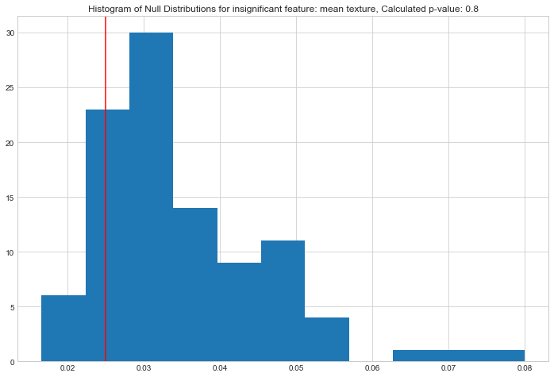

```python
get_hist(p_values=p_values, baseline_score=shap_baseline, imp_scores=shap_imp, features=cols, n=1)
```

**Mean Texture** has an empirical p-value > 0.05 and has a high chance of coming from the Null distribution. Hence we deem this feature **insignificant**.

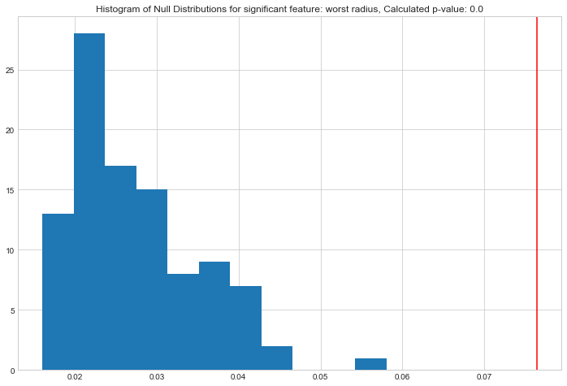

```python
get_hist(p_values=p_values, baseline_score=shap_baseline, imp_scores=shap_imp, features=cols, n=20)
```

**Worst Radius** has an empirical p-value of ~ 0 and hence almost no chance of belonging to the Null distribution. Hence we deem this feature **significant**.